# Movie recommendation engine part 1

### Project details:

#### Domain: Entertainment

#### Project: IMDB - Recommendation

#### Data: movie_metadata.csv

#### Description

- This dataset contains 28 variables for 5043 movies, spanning across 100 years in 66 countries. There are 2399 unique director names, and thousands of actors/actresses. Below are the 28 variables:

movie_title  
color  
num_critic_for_reviews  
movie_facebook_likes  
duration  
director_name  
director_facebook_likes  
actor_3_name  
actor_3_facebook_likes  
actor_2_name  
actor_2_facebook_likes  
actor_1_name  
actor_1_facebook_likes  
gross  
genres  
num_voted_users  
cast_total_facebook_likes  
facenumber_in_poster  
plot_keywords  
movie_imdb_link  
num_user_for_reviews  
language  
country  
content_rating  
budget  
title_year  
imdb_score  
aspect_ratio

#### Objective

- Given that thousands of movies were produced each year, is there a better way for us to tell the greatness of movie without relying on critics or our own instincts? (Part 1)
- And try to create a recommendation engine with this dataset. (Part 2)

### Loading required packages

```r
library(tidyr)
library(dplyr)
library(reshape2)
```

```r
library(ggplot2)
```

### Loading the data

```r
movies <- read.csv('movie_metadata.csv',stringsAsFactors=FALSE)
glimpse(movies)
```

```
## Observations: 5,043
## Variables: 28
## $ color                     <chr> "Color", "Color", "Color", "Color", ...
## $ director_name             <chr> "James Cameron", "Gore Verbinski", "...
## $ num_critic_for_reviews    <int> 723, 302, 602, 813, NA, 462, 392, 32...
## $ duration                  <int> 178, 169, 148, 164, NA, 132, 156, 10...
## $ director_facebook_likes   <int> 0, 563, 0, 22000, 131, 475, 0, 15, 0...
## $ actor_3_facebook_likes    <int> 855, 1000, 161, 23000, NA, 530, 4000...
## $ actor_2_name              <chr> "Joel David Moore", "Orlando Bloom",...
## $ actor_1_facebook_likes    <int> 1000, 40000, 11000, 27000, 131, 640,...
## $ gross                     <int> 760505847, 309404152, 200074175, 448...
## $ genres                    <chr> "Action|Adventure|Fantasy|Sci-Fi", "...
## $ actor_1_name              <chr> "CCH Pounder", "Johnny Depp", "Chris...
## $ movie_title               <chr> "AvatarÂ ", "Pirates of the Caribbea...
## $ num_voted_users           <int> 886204, 471220, 275868, 1144337, 8, ...
## $ cast_total_facebook_likes <int> 4834, 48350, 11700, 106759, 143, 187...
## $ actor_3_name              <chr> "Wes Studi", "Jack Davenport", "Step...
## $ facenumber_in_poster      <int> 0, 0, 1, 0, 0, 1, 0, 1, 4, 3, 0, 0, ...
## $ plot_keywords             <chr> "avatar|future|marine|native|paraple...
## $ movie_imdb_link           <chr> "http://www.imdb.com/title/tt0499549...
## $ num_user_for_reviews      <int> 3054, 1238, 994, 2701, NA, 738, 1902...
## $ language                  <chr> "English", "English", "English", "En...
## $ country                   <chr> "USA", "USA", "UK", "USA", "", "USA"...
## $ content_rating            <chr> "PG-13", "PG-13", "PG-13", "PG-13", ...
## $ budget                    <dbl> 237000000, 300000000, 245000000, 250...
## $ title_year                <int> 2009, 2007, 2015, 2012, NA, 2012, 20...
## $ actor_2_facebook_likes    <int> 936, 5000, 393, 23000, 12, 632, 1100...
## $ imdb_score                <dbl> 7.9, 7.1, 6.8, 8.5, 7.1, 6.6, 6.2, 7...
## $ aspect_ratio              <dbl> 1.78, 2.35, 2.35, 2.35, NA, 2.35, 2....
## $ movie_facebook_likes      <int> 33000, 0, 85000, 164000, 0, 24000, 0...
```

```r
summary(movies)
```

```
##     color           director_name      num_critic_for_reviews
##  Length:5043        Length:5043        Min.   :  1.0
##  Class :character   Class :character   1st Qu.: 50.0
##  Mode  :character   Mode  :character   Median :110.0
##                                        Mean   :140.2
##                                        3rd Qu.:195.0
##                                        Max.   :813.0
##                                        NA's   :50
##     duration     director_facebook_likes actor_3_facebook_likes
##  Min.   :  7.0   Min.   :    0.0         Min.   :    0.0
##  1st Qu.: 93.0   1st Qu.:    7.0         1st Qu.:  133.0
##  Median :103.0   Median :   49.0         Median :  371.5
##  Mean   :107.2   Mean   :  686.5         Mean   :  645.0
##  3rd Qu.:118.0   3rd Qu.:  194.5         3rd Qu.:  636.0
##  Max.   :511.0   Max.   :23000.0         Max.   :23000.0
##  NA's   :15      NA's   :104             NA's   :23
##  actor_2_name       actor_1_facebook_likes     gross
##  Length:5043        Min.   :     0         Min.   :      162
##  Class :character   1st Qu.:   614         1st Qu.:  5340988
##  Mode  :character   Median :   988         Median : 25517500
##                     Mean   :  6560         Mean   : 48468408
##                     3rd Qu.: 11000         3rd Qu.: 62309438
##                     Max.   :640000         Max.   :760505847
##                     NA's   :7              NA's   :884
##     genres          actor_1_name       movie_title
##  Length:5043        Length:5043        Length:5043
##  Class :character   Class :character   Class :character
##  Mode  :character   Mode  :character   Mode  :character
##
##
##
##
##  num_voted_users   cast_total_facebook_likes actor_3_name
##  Min.   :      5   Min.   :     0            Length:5043
##  1st Qu.:   8594   1st Qu.:  1411            Class :character
##  Median :  34359   Median :  3090            Mode  :character
##  Mean   :  83668   Mean   :  9699
##  3rd Qu.:  96309   3rd Qu.: 13756
##  Max.   :1689764   Max.   :656730
##
```

[output cut: 25 more lines]

```
##  Min.   :     0         Min.   :1.600   Min.   : 1.18
##  1st Qu.:   281         1st Qu.:5.800   1st Qu.: 1.85
##  Median :   595         Median :6.600   Median : 2.35
##  Mean   :  1652         Mean   :6.442   Mean   : 2.22
##  3rd Qu.:   918         3rd Qu.:7.200   3rd Qu.: 2.35
##  Max.   :137000         Max.   :9.500   Max.   :16.00
##  NA's   :13                             NA's   :329
##  movie_facebook_likes
##  Min.   :     0
##  1st Qu.:     0
##  Median :   166
##  Mean   :  7526
##  3rd Qu.:  3000
##  Max.   :349000
##
```

The missing values are present in:

num_critic_for_reviews(50)  
duration(15)  
director_facebbok_likes(104)  
actor_3_facebook_likes(23)  
actor_1_facebook_likes(7)  
gross(884)  
facenumber_in_poster(13)  
num_user_for_reviews(21)  
budget(492)  
title_year(108)  
actor_2_facebook_likes(13)  
aspect_ratio(329)

### Removing the duplcate movies

```r
idx_dup <- which(duplicated(movies$movie_title)==TRUE)
movies <- movies[-idx_dup,]
```

### Finding columns and rows with missing values using function

```r
miss <- function(x) {
 cat('\nThe columns having missing values are:')
 for(i in 1:ncol(x)) {
  if(length(x[i][is.na(x[i])]) > 0) {
    cat('\n',names(x[i]),':',length(x[i][is.na(x[i])]))
  }
 }
  cat('\n\nThe number of rows with missing values are:',nrow(x)-nrow(na.omit(x)))
  cat('\nThe proportion of missing values is:',signif((nrow(x)-nrow(na.omit(x)))/nrow(x),2))
}

miss(movies)
```

```
##
## The columns having missing values are:
##  num_critic_for_reviews : 49
##  duration : 15
##  director_facebook_likes : 102
##  actor_3_facebook_likes : 23
##  actor_1_facebook_likes : 7
##  gross : 863
##  facenumber_in_poster : 13
##  num_user_for_reviews : 21
##  budget : 484
##  title_year : 106
##  actor_2_facebook_likes : 13
##  aspect_ratio : 326
##
## The number of rows with missing values are: 1217
## The proportion of missing values is: 0.25
```

### Removing rows with missing values in budget and gross

### Missing values in rest of the columns can be replaced with zeros

```r
# remove the rows having missing values in budget and gross
idx <- which(is.na(movies$budget)==TRUE)
movies <- movies[-idx,]

idx <- which(is.na(movies$gross)==TRUE)
movies <- movies[-idx,]

# replace with zeros
movies[is.na(movies)] <- 0

# checking the missing values
miss(movies)
```

```
##
## The columns having missing values are:
##
## The number of rows with missing values are: 0
## The proportion of missing values is: 0
```

Now the dataset is clean and ready

### Write into csv file so as to do visualizations in tableau

### check the Visualizations here:

https://public.tableau.com/profile/bharadwaj.tadikonda#!/vizhome/Imdb_recommendation/ImdbscorevsNumvotedUsers

```r
write.csv(movies,'movies_tab.csv')
```

Can infer the following from plots:

- Majority of the scores are in range of 6-8
- Countries like China, Hong kong, India, Italy, Japan, Mexico, Spain, UK have produced the average score of above 7 (min. count of movies is 10)
- UK produced lots of movies (313) with average Imdb score of 7
- US produced largest number of movies(2993), however their average imdb score is 6.5
- We can find that over the years(spcifically after 1975) the quality of movies(as per score) has come down. This might be partly due to the fact that large number of movies are being made.
- As the “movie facebook likes” increases, the score also increases. There are few outliers too like for instance “Interstellar” got the maximum likes(>350k) but score is only 8.6 where as “Godfather” got less than 50k likes but its score is 9.2
- There is positive relationship between “cast total FB likes” and Imdb score, however its not as strong as that of “movie facebook likes”
- As the duration of movie increases, the score also increases
- Generally speaking as the score of movie increases, the gross also increases. However the budgets for high gross earning movies is also high. For instance, movie like “Avatar” which made whopping gross had gross profit margin of 69% where as “A separation” made on comparitively less budget made gross profit margin of 93%
- The most succesful director(with min. 10 movies) is steven spielberg (both in terms of score and gross profit margin %)
- The Top actor score wise(with min. 10 movies) are Tom hanks, Leonardo Dicaprio and Clint Eastwood
- The Top actor-director combination(with min. 3 movies together) are Christain Bale-Christopher Nolan, Robert De Niro -Martin Scorsese, Leonardo Dicaprio -Martin Scorsese, Michael Biehn-James Cameron, Michael Moore-Michael Moore.
- More the “Num Voted users”, better is the score. The movie with highest votes is “The shawshank Redemption”(9.3), followed by “The Dark Knight”(9) and “Inception”(8.8)

### Correlation analysis

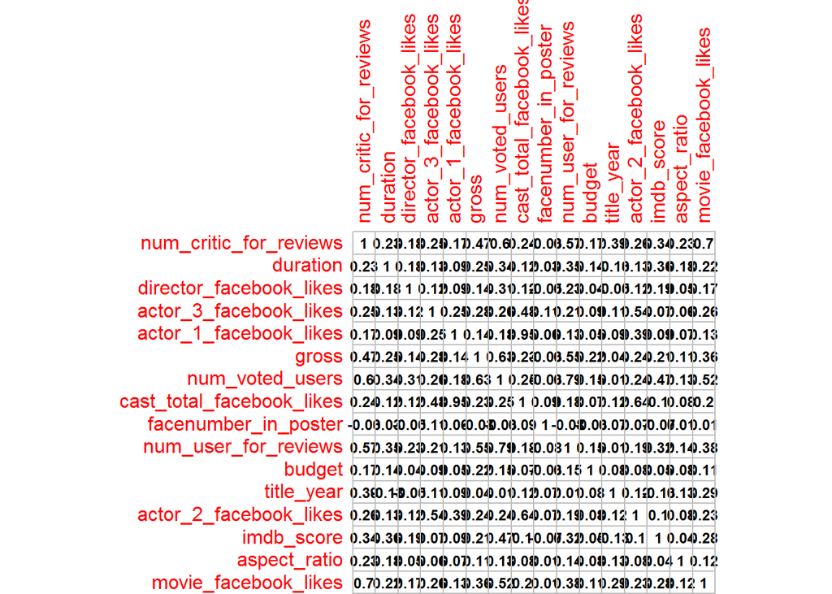

```r
library(corrplot)
x <- cor(movies[,unlist(lapply(movies, is.numeric))])

#corrplot(x,method='number',number.cex=0.75,col='blue')
corrplot(x,method='number',col='black',cl.pos = "n",number.cex=0.75)
```

```r
xdf <- as.data.frame(as.table(x))
xdf <- xdf %>% filter(abs(Freq) > 0.5 & Freq != 1) %>% arrange(desc(Freq))

xdf
```

```
##                         Var1                      Var2      Freq
## 1  cast_total_facebook_likes    actor_1_facebook_likes 0.9470115
## 2     actor_1_facebook_likes cast_total_facebook_likes 0.9470115
## 3       num_user_for_reviews           num_voted_users 0.7865262
## 4            num_voted_users      num_user_for_reviews 0.7865262
## 5       movie_facebook_likes    num_critic_for_reviews 0.7032383
## 6     num_critic_for_reviews      movie_facebook_likes 0.7032383
## 7     actor_2_facebook_likes cast_total_facebook_likes 0.6360456
## 8  cast_total_facebook_likes    actor_2_facebook_likes 0.6360456
## 9            num_voted_users                     gross 0.6301043
## 10                     gross           num_voted_users 0.6301043
## 11           num_voted_users    num_critic_for_reviews 0.5992754
## 12    num_critic_for_reviews           num_voted_users 0.5992754
## 13      num_user_for_reviews    num_critic_for_reviews 0.5696833
## 14    num_critic_for_reviews      num_user_for_reviews 0.5696833
## 15      num_user_for_reviews                     gross 0.5511666
## 16                     gross      num_user_for_reviews 0.5511666
## 17    actor_2_facebook_likes    actor_3_facebook_likes 0.5446500
## 18    actor_3_facebook_likes    actor_2_facebook_likes 0.5446500
## 19      movie_facebook_likes           num_voted_users 0.5235137
## 20           num_voted_users      movie_facebook_likes 0.5235137
```

Can infer that:

- The “imdb_score” has positive correlation with “num_voted_users”. More the voted users, movies tend to have high rating.
- The “imdb_score” has small but positive correlation with “duration”. Long movies tend to have high rating.
- The “imdb_score” has very small but positive correlation with the “director_facebook_likes”, meaning a popular director does not necessarily mean his directed movie is great.
- The “imdb_score” has very small but positive correlation with the “actor_1_facebook_likes”, meaning that an leading actor is popular in social network does not mean that a movie is high rating
- The “imdb_score” has small but negative correlation with “facenumber_in_poster”. It is perhaps not a good idea to have many faces in movie poster if a movie wants to be great.
- The “imdb_score” has almost no correlation with “budget”. Throwing money at a movie will not necessarily make it great.
- The “cast_total_facebook_likes” has a strong positive correlation with the “actor_1_facebook_likes”, and has smaller positive correlation with both “actor_2_facebook_likes” and “actor_3_facebook_likes”
- The “num_user_for_reviews” & “num_critic_for_reviews”" has strong positive correlation with the “num_voted_users”, meaning the users who write reviews and are critics also vote for the movie
- The “movie_facebook_likes” has strong correlation with “num_critic_for_reviews”, meaning that the popularity of a movie in social network can be largely affected by the critics
- The movie “gross” has strong positive correlation with the “num_voted_users”
- The “movie_facebook_likes” has relatively large correlation with the “num_voted_users”

### Correlation implies linear relationship. Let’s validate it through scatter plot

### Multicollinearity should not exist for linear regression

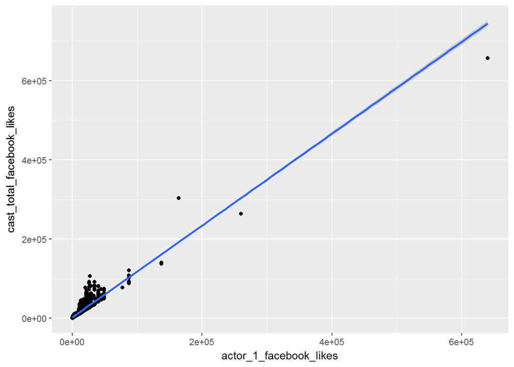

```r
ggplot(movies,aes(actor_1_facebook_likes,cast_total_facebook_likes))+geom_point()+geom_smooth(method = 'lm')
```

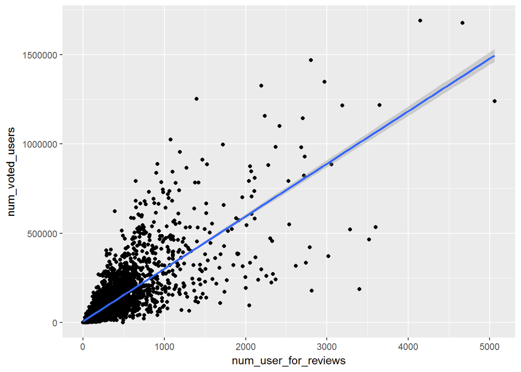

```r
ggplot(movies,aes(num_user_for_reviews,num_voted_users))+geom_point()+geom_smooth(method = 'lm')
```

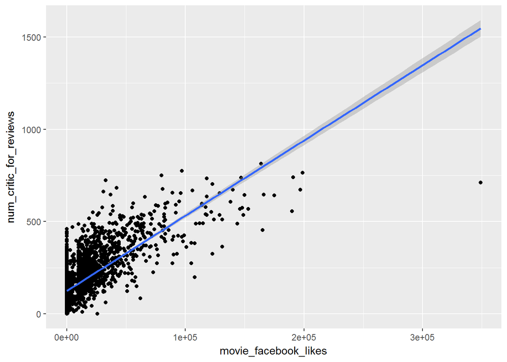

```r
ggplot(movies,aes(movie_facebook_likes,num_critic_for_reviews))+geom_point()+geom_smooth(method = 'lm')
```

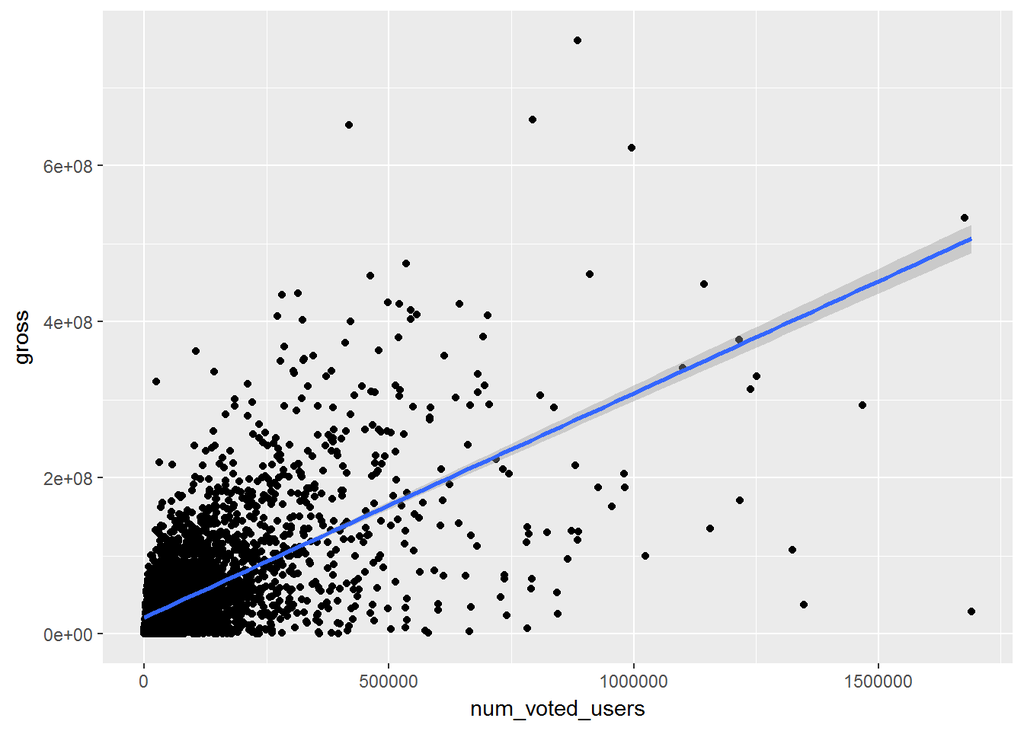

```r
ggplot(movies,aes(num_voted_users,gross))+geom_point()+geom_smooth(method = 'lm')
```

### Selecting the variables for linear regression

```r
#remove variables that correspond to post release
  #num_critic_for_reviews
  #gross
  #num_voted_users
  #num_user_for_reviews
  #movie_facebook_likes

#remove variables having high collinearity
  #cast_total_facebook_likes

#remove other variables
  #genres
  #plot_keywords
  #movie_imdb_link
  #director_name
  #actor_1_name
  #actor_2_name
  #actor_3_name
  #movie_title
  #country
```

### Split the data into train and test

```r
# removing the variables

#movies_sub <- movies %>% select(-c(num_critic_for_reviews, gross, num_voted_users, num_user_for_reviews, movie_facebook_likes, cast_total_facebook_likes, genres, plot_keywords, movie_imdb_link,director_name,actor_1_name,actor_2_name,actor_3_name,movie_title,country,aspect_ratio))

#divide the new data

library(caret)
set.seed(100)
idx <- createDataPartition(movies$imdb_score,p=0.7,list = FALSE)

movies_train <- movies[idx,]
movies_test <- movies[-idx,]

#standardise the data
movies_train1 <- movies_train
movies_test1 <- movies_test

movies_train1[,c(3:6,8:9,13:14,19,23,25,28)] <- scale(movies_train1[,c(3:6,8:9,13:14,19,23,25,28)], center = TRUE, scale = TRUE)

movies_test1[,c(3:6,8:9,13:14,19,23,25,28)] <- scale(movies_test1[,c(3:6,8:9,13:14,19,23,25,28)], center = TRUE, scale = TRUE)
```

### Defining parameters

```r
#Define the training control

fitcontrol <- trainControl(method="cv",number=10,savePredictions='final')
fitcontrol1 <- trainControl(method="cv",number=10,savePredictions='final',search = "grid")

#fitcontrol <- trainControl(savePredictions='final')

#Defind predictors and outcome

#predictors <- c("duration","director_facebook_likes","actor_3_facebook_likes","actor_1_facebook_likes","facenumber_in_poster","content_rating","budget","title_year","actor_2_facebook_likes","language","color","aspect_ratio")
predictors <- c("duration","director_facebook_likes","actor_3_facebook_likes","actor_1_facebook_likes","facenumber_in_poster","budget","title_year","actor_2_facebook_likes")


outcome <- "imdb_score"
```

### Initializing the results table

```r
prediction <- data.frame()
RMSE <- NULL
R2 <- NULL
```

### Creating error measures(RMSE, Rsquared) to validate the model

### RMSE : Root Mean squared Error. It tells the error in prediction

### Rsquared: It tells the poportion of variance explained by the model

```r
Error_measures <- function(actual,predicted)
{
  SSE <- sum((actual-predicted)^2)
  SST <- sum((actual-mean(actual))^2)

  R2 <<- 1-(SSE/SST)

  error <- actual-predicted
  RMSE <<- sqrt(mean(error^2))
}
```

### Linear Regression Training

```r
set.seed(101)
model_lm <- train(movies_train1[,predictors],
                  movies_train1[,outcome],
                  method = 'lm',
                  #preProcess = c('center','scale'),
                  tuneLength = 9,
                  trControl = fitcontrol)

model_lm
```

```
## Linear Regression
##
## 2653 samples
##    8 predictor
##
## No pre-processing
## Resampling: Cross-Validated (10 fold)
## Summary of sample sizes: 2388, 2387, 2389, 2387, 2387, 2388, ...
## Resampling results:
##
##   RMSE       Rsquared
##   0.9687982  0.1538583
##
## Tuning parameter 'intercept' was held constant at a value of TRUE
```

### Validating Linear Regression Assumptions

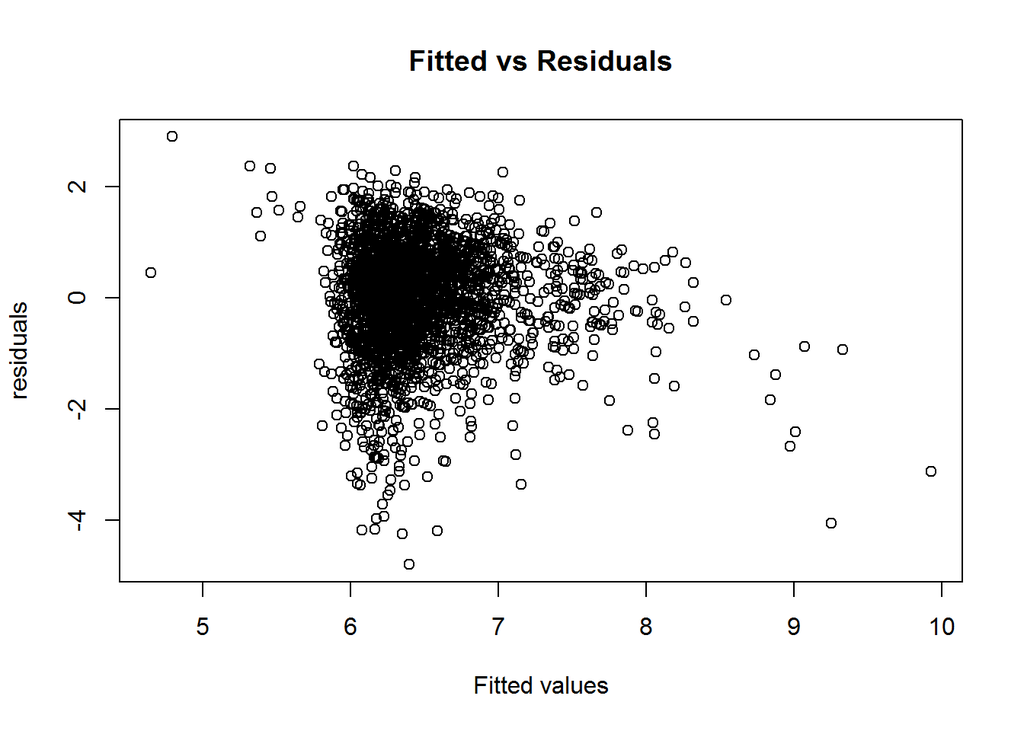

```r
#Linearity & Homoscedasticity

residuals <- model_lm$pred[,'obs']-model_lm$pred[,'pred']
plot(model_lm$pred[,'pred'],residuals,xlab='Fitted values',main="Fitted vs Residuals")
```

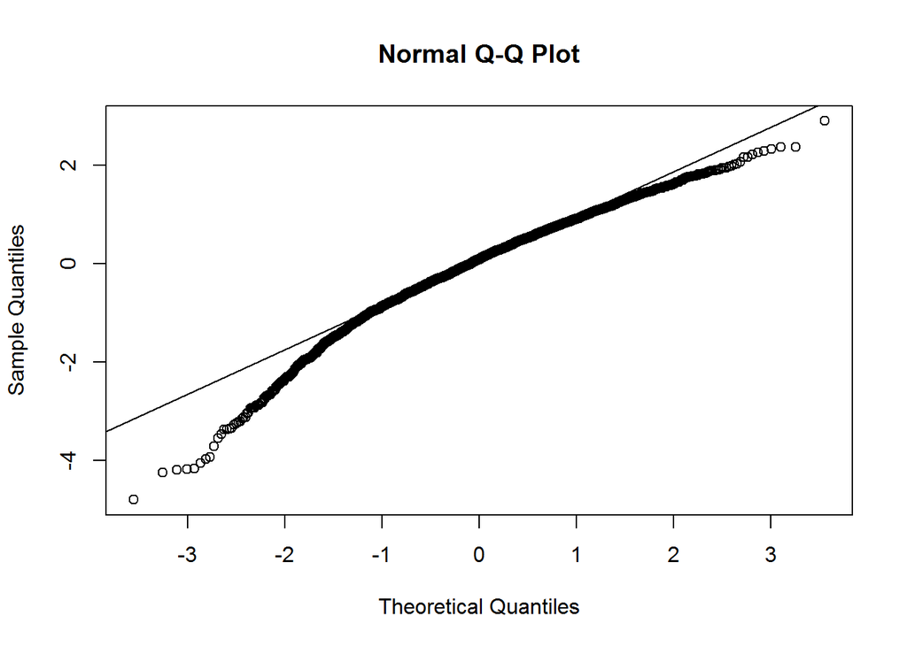

```r
#Normality

qqnorm(residuals)
qqline(residuals)
```

```r
#Multicollinearity
library(car)
vif(model_lm$finalModel)
```

```
##                duration director_facebook_likes  actor_3_facebook_likes
##                1.085659                1.068071                1.420134
##  actor_1_facebook_likes    facenumber_in_poster                  budget
##                1.366834                1.027052                1.031903
##              title_year  actor_2_facebook_likes
##                1.060651                1.715223
```

Can infer that:

- Linearity & homoscedasticity exists(though not perfect)
- Normality exists(though slight deviation)
- VIF<=4, so we can say multicollinearity doesnot exist between the predictor variables
- Since all these assumptions hold good, we can proceed with linear regression model

### Linear Regression Validation

```r
#prediction
predict_model_lm <- predict(model_lm,movies_test1[,predictors])

#calculating error measures
Error_measures(movies_test1$imdb_score,predict_model_lm)

#Building the result into table
prediction <<- prediction[-1,]
temp1 <- data.frame(RMSE=RMSE,Rsquared=R2)
prediction <<- rbind(prediction, lin_reg=temp1 )
prediction['lin_reg',]
```

```
##             RMSE  Rsquared
## lin_reg 0.979591 0.1756833
```

### Decision Tree Training

```r
set.seed(101)
model_rpart <- train(movies_train1[,predictors],
                  movies_train1[,outcome],
                  method = 'rpart',
                  tuneLength = 9,
                  trControl = fitcontrol)
model_rpart
```

```
## CART
##
## 2653 samples
##    8 predictor
##
## No pre-processing
## Resampling: Cross-Validated (10 fold)
## Summary of sample sizes: 2388, 2387, 2389, 2387, 2387, 2388, ...
## Resampling results across tuning parameters:
##
##   cp           RMSE       Rsquared
##   0.007815744  0.9465109  0.19155477
##   0.008204833  0.9492055  0.18724212
##   0.008974289  0.9542428  0.17890200
##   0.009103523  0.9530949  0.18015785
##   0.011400987  0.9634293  0.16241194
##   0.015046414  0.9737716  0.14473804
##   0.017710725  0.9786556  0.13465297
##   0.024589436  0.9823691  0.12753626
##   0.122990385  1.0333781  0.07639421
##
## RMSE was used to select the optimal model using  the smallest value.
## The final value used for the model was cp = 0.007815744.
```

### Decision Tree Validation

```r
#prediction
predict_model_rpart <- predict(model_rpart,movies_test1[,predictors])

#calculating error measures
Error_measures(movies_test1$imdb_score,predict_model_rpart)

#Building the result into table
prediction <<- prediction[-2,]
temp1 <- data.frame(RMSE=RMSE,Rsquared=R2)
prediction <<- rbind(prediction, decision_tree=temp1 )
prediction['decision_tree',]
```

```
##                   RMSE  Rsquared
## decision_tree 1.005038 0.1323009
```

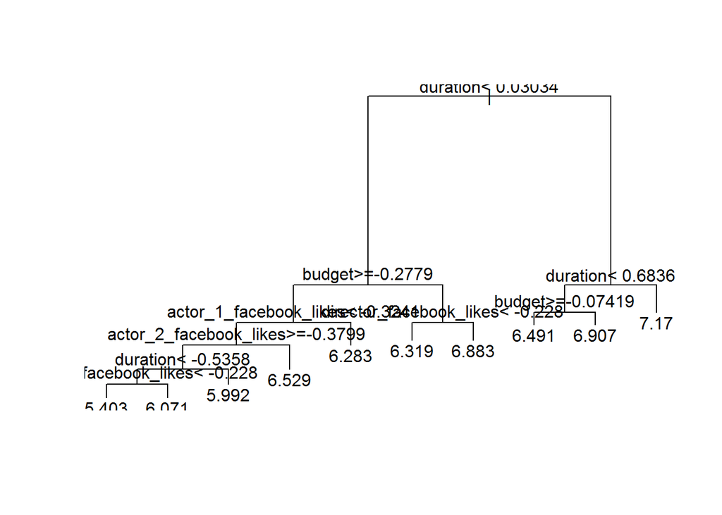

```r
#plot the tree
plot(model_rpart$finalModel)
text(model_rpart$finalModel)
```

### random forest training

```r
set.seed(101)
model_rf <- train(movies_train1[,predictors],
                  movies_train1[,outcome],
                  method = 'rf',
                  importance = TRUE,
                  tuneLength = 7,
                  trControl = fitcontrol)
model_rf
```

```
## Random Forest
##
## 2653 samples
##    8 predictor
##
## No pre-processing
## Resampling: Cross-Validated (10 fold)
## Summary of sample sizes: 2388, 2387, 2389, 2387, 2387, 2388, ...
## Resampling results across tuning parameters:
##
##   mtry  RMSE       Rsquared
##   2     0.8771512  0.3038204
##   3     0.8776740  0.3025403
##   4     0.8793713  0.2993280
##   5     0.8798977  0.2989754
##   6     0.8813205  0.2969679
##   7     0.8825904  0.2951940
##   8     0.8847681  0.2921658
##
## RMSE was used to select the optimal model using  the smallest value.
## The final value used for the model was mtry = 2.
```

### random forest Validation

```r
#prediction
predict_model_rf <- predict(model_rf,movies_test1[,predictors])

#calculating error measures
Error_measures(movies_test1$imdb_score,predict_model_rf)

#Building the result into table
prediction <<- prediction[-3,]
temp1 <- data.frame(RMSE=RMSE,Rsquared=R2)
prediction <<- rbind(prediction, random_forest=temp1 )
prediction['random_forest',]
```

```
##                    RMSE  Rsquared
## random_forest 0.9496688 0.2252726
```

### Plot the error in random forest model

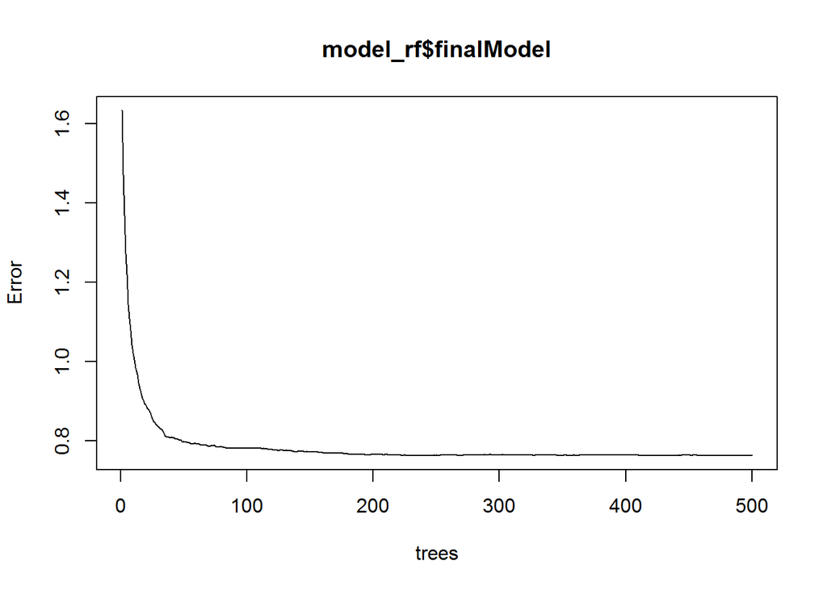

```r
#plot the error
plot(model_rf$finalModel)
```

Can infer that:

- Initially there is lot of volatility but the curve stabilizes after around 50 trees

### Variable importance

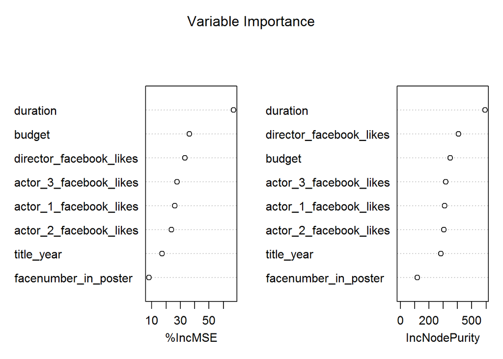

```r
#check the variables important to the model

#varImp(model_rf$finalModel)
varImpPlot(model_rf$finalModel,main="Variable Importance")
```

Can infer that:

- The most important factor affecting movie rating are as follows:
  - duration
  - budget
  - director popularity on facebook
  - Top 3 actors popularity on facebook
  - title year
  - facenumber in poster

### K nearest neighbours training

```r
set.seed(101)
model_knn <- train(movies_train1[,predictors],
                  movies_train1[,outcome],
                  method = 'knn',
                  tuneLength = 30,
                  trControl = fitcontrol)

model_knn
```

```
## k-Nearest Neighbors
##
## 2653 samples
##    8 predictor
##
## No pre-processing
## Resampling: Cross-Validated (10 fold)
## Summary of sample sizes: 2388, 2387, 2389, 2387, 2387, 2388, ...
## Resampling results across tuning parameters:
##
##   k   RMSE       Rsquared
##    5  1.0241330  0.1103599
##    7  1.0077596  0.1144320
##    9  0.9996082  0.1181346
##   11  0.9929203  0.1246034
```

[output cut: 29 more lines]

### K nearest neighbours Validation

```r
#prediction
predict_model_knn <- predict(model_knn,movies_test1[,predictors])

#calculating error measures
Error_measures(movies_test1$imdb_score,predict_model_knn)

#Building the result into table
prediction <<- prediction[-4,]
temp1 <- data.frame(RMSE=RMSE,Rsquared=R2)
prediction <<- rbind(prediction, knn=temp1 )
prediction['knn',]
```

```
##          RMSE  Rsquared
## knn 0.9864262 0.1641396
```

### Support vector machines Training

```r
set.seed(101)

fitcontrol1 <- trainControl(method="cv",number=10,savePredictions='final',search = "grid")

#Grid <- expand.grid(.C=c(0.001,0.01,0.1,1,10))
Grid <- expand.grid(.C=10^(-3:1))

model_svm <- train(movies_train1[,predictors],
                  movies_train1[,outcome],
                  method = 'svmLinear',
                  tuneGrid = Grid,
                  trControl = fitcontrol1)
model_svm
```

```
## Support Vector Machines with Linear Kernel
##
## 2653 samples
##    8 predictor
##
## No pre-processing
## Resampling: Cross-Validated (10 fold)
## Summary of sample sizes: 2388, 2387, 2389, 2387, 2387, 2388, ...
## Resampling results across tuning parameters:
##
##   C      RMSE       Rsquared
##   1e-03  0.9777423  0.1527942
##   1e-02  0.9778099  0.1468401
##   1e-01  0.9829644  0.1439213
##   1e+00  0.9836445  0.1433705
##   1e+01  0.9836238  0.1433759
##
## RMSE was used to select the optimal model using  the smallest value.
## The final value used for the model was C = 0.001.
```

### Support vector machines Validation

```r
#prediction
predict_model_svm <- predict(model_svm,movies_test1[,predictors])

#calculating error measures
Error_measures(movies_test1$imdb_score,predict_model_svm)

#Building the result into table
prediction <<- prediction[-5,]
temp1 <- data.frame(RMSE=RMSE,Rsquared=R2)
prediction <<- rbind(prediction, svm_linear=temp1 )
prediction['svm_linear',]
```

```
##                 RMSE  Rsquared
## svm_linear 0.9946627 0.1501227
```

### PCA

```r
#load library
library(dummies)
```

```r
#create a dummy data frame
new_my_data <- dummy.data.frame(movies, names = c("content_rating","language", "color"))



#divide the new data
pca.train <- new_my_data[idx,]
pca.test <- new_my_data[-idx,]


predictors2_exclude <- c("num_critic_for_reviews", "gross", "num_voted_users", "num_user_for_reviews", "movie_facebook_likes", "cast_total_facebook_likes", "genres", "plot_keywords", "movie_imdb_link", "director_name", "actor_1_name", "actor_2_name", "actor_3_name", "movie_title", "country", "imdb_score")


outcome <- "imdb_score"

#extra variables used for PCA are: "content_rating","language","color","aspect_ratio"
predictors2 <- names(pca.train)[!(names(pca.train) %in% predictors2_exclude)]



#checking columns having variance of 0. These need to be eliminated in order for PCA to function
i <- which(apply(pca.train[,predictors2],2,var)==0)


#principal component analysis
prin_comp <- prcomp(pca.train[,predictors2[-i]],scale. = T)

names(prin_comp)
```

```
## [1] "sdev"     "rotation" "center"   "scale"    "x"
```

```r
#principal component loading
prin_comp$rotation[1:5,]
```

```
##                                 PC1         PC2          PC3         PC4
## color                   -0.01610807  0.04101791 -0.003981507  0.04153533
## color Black and White   -0.35443319  0.49460261 -0.090790491  0.04866957
## colorColor               0.35422831 -0.49632626  0.090722326 -0.05290382
## duration                 0.06531985  0.15046523 -0.290236947 -0.12099192
## director_facebook_likes  0.08685053  0.17631832 -0.154712041 -0.09066472
##                                  PC5         PC6        PC7          PC8
## color                   -0.008526703  0.06399882 -0.1028218  0.005866114
## color Black and White   -0.015762562  0.05913137 -0.2035432  0.103562608
## colorColor               0.016600037 -0.06574292  0.2135680 -0.103628420
## duration                -0.106281215  0.07208713  0.1214325 -0.384141989
## director_facebook_likes -0.025802583 -0.07513602  0.1659445 -0.005980934
##                                 PC9        PC10        PC11        PC12
## color                   -0.04749666  0.05093360 -0.06045731  0.02110843
## color Black and White   -0.05968251  0.01697550  0.01075728  0.02464152
## colorColor               0.06450231 -0.02240291 -0.00414491 -0.02679389
## duration                 0.04704438  0.20680885  0.07307775 -0.21683281
## director_facebook_likes -0.05270337  0.16360745 -0.22260694 -0.20675223
##                                PC13         PC14         PC15        PC16
## color                   -0.08252128  0.088545346 -0.074674954 -0.08061659
## color Black and White   -0.04826021  0.005287876  0.004783674 -0.02536172
## colorColor               0.05693931 -0.014856477  0.003336908  0.03396040
## duration                 0.08350630 -0.139280995 -0.030356218 -0.06696681
## director_facebook_likes  0.18570490  0.197172815  0.279463942 -0.06564564
##                                 PC17          PC18          PC19
## color                    0.736392471 -0.0906900086 -0.3190441835
## color Black and White   -0.042547475  0.0027252025  0.0177645788
## colorColor              -0.037506598  0.0071199712  0.0169153981
## duration                -0.002832846  0.0004400673 -0.0007373159
## director_facebook_likes -0.000409159 -0.0040429517 -0.0033515029
##                                  PC20         PC21          PC22
## color                   -0.1258964055 -0.073976584 -6.134343e-02
## color Black and White    0.0090404478  0.004638723  3.396343e-03
## colorColor               0.0046556180  0.003405363  3.271558e-03
## duration                -0.0006006425 -0.001267700  1.572403e-06
## director_facebook_likes  0.0026125960 -0.002135855 -5.967066e-05
##                                 PC23          PC24          PC25
## color                   -0.042957610 -0.0120875750 -0.1129186802
## color Black and White    0.003282910 -0.0003600931  0.0066531100
## colorColor               0.001391470  0.0016683211  0.0056231190
```

[output cut: 59 more lines]

```
## colorColor               0.01664231  0.03330901 -0.0050543566 -0.032163121
## duration                 0.04090754 -0.53351672 -0.2558974599  0.248035961
## director_facebook_likes  0.14934801  0.28752483 -0.0118507897  0.042010851
##                                 PC59         PC60          PC61
## color                    0.006285846 -0.009544282  7.653732e-02
## color Black and White   -0.001925252  0.006443184  7.022220e-01
## colorColor               0.001233312 -0.005373184  7.061086e-01
## duration                -0.117302129  0.114766374  1.665335e-16
## director_facebook_likes -0.043058614 -0.061295538 -2.498002e-16
##                                  PC62         PC63
## color                    3.439467e-03 1.574716e-03
## color Black and White    3.155675e-02 1.444786e-02
## colorColor               3.173141e-02 1.452782e-02
## duration                 9.922618e-16 1.656661e-16
## director_facebook_likes -2.949030e-16 6.071532e-18
```

```r
#True value of transformed data
head(prin_comp$x)
```

```
##          PC1          PC2        PC3        PC4        PC5         PC6
## 1  0.7782759 -0.006649726 -1.1300062  1.1331727 -1.1068697  0.35469311
## 3  1.2754040 -0.157725976 -1.1510269  1.0915409 -0.9816532  0.71750329
## 4  7.3005093  5.519229199 -6.9159865 -0.4829394  1.6070428 -1.77139266
## 6  0.9874755 -0.324849166 -0.8773877  1.2522590 -1.1332687  0.62630693
## 7  2.6933520  1.272304685 -2.4632990  0.6928117 -0.3835600  0.04546678
## 10 3.2937670  1.925004380 -2.7452492  0.2189532  0.1934253 -1.77517376
##           PC7        PC8         PC9       PC10        PC11        PC12
## 1  -0.3449574 -1.4991598  0.28425684 0.30710824 -0.48439478 -0.49992531
## 3  -0.9258574 -1.0307597  0.13069105 0.33793522 -0.08226464 -0.30697961
## 4   3.8564570  1.4425566 -0.33236643 0.36634878 -2.54999166 -0.35309242
## 6  -0.9374579 -0.8847558  0.11111598 0.20986039 -0.12592493 -0.22497483
## 7   0.3814702 -0.4932874  0.14577175 0.07179104 -0.57718370  0.09587423
## 10  1.6758310  1.7523936  0.03414091 0.73157428  1.35702541  0.24558536
##           PC13         PC14       PC15       PC16          PC17
```

[output cut: 69 more lines]

### PCA plots

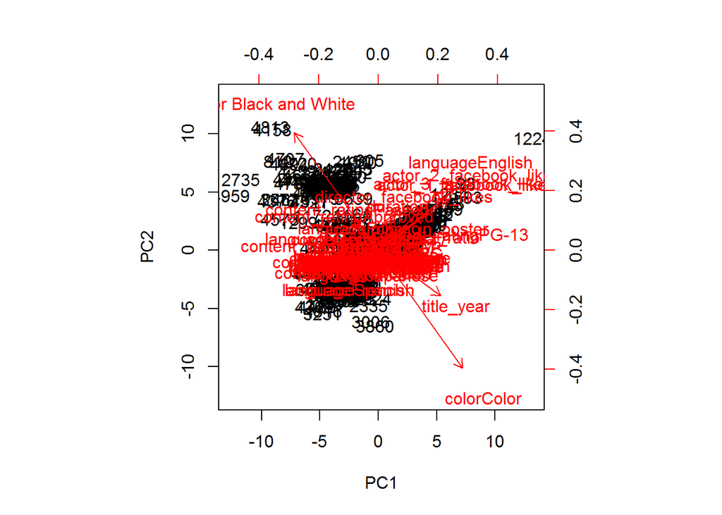

```r
biplot(prin_comp,scale=0)
```

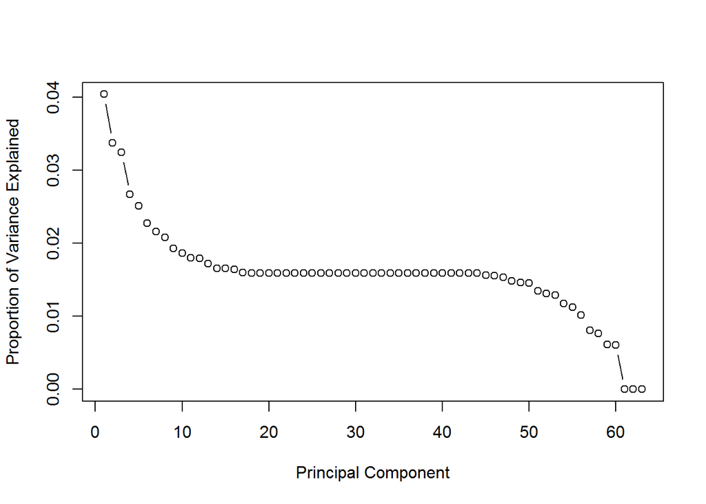

```r
#compute standard deviation of each principal component
std_dev <- prin_comp$sdev

#compute variance
pr_var <- std_dev^2

#proportion of variance explained
prop_varex <- pr_var/sum(pr_var)

#scree plot
plot(prop_varex, xlab = "Principal Component",
             ylab = "Proportion of Variance Explained",
             type = "b")
```

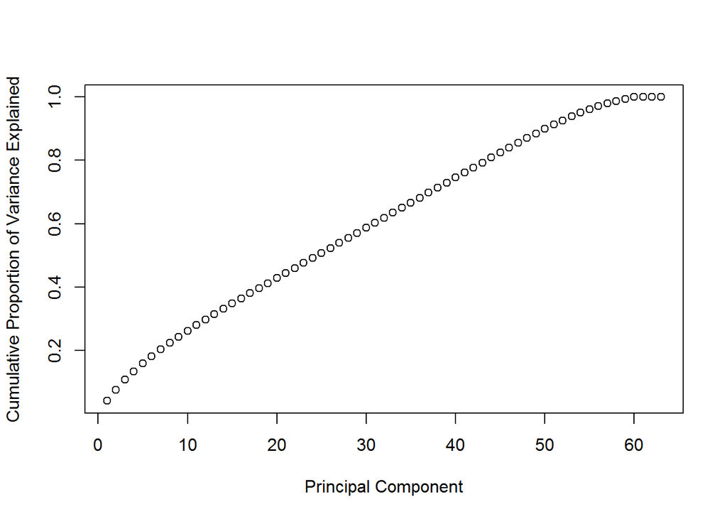

```r
#cumulative scree plot
plot(cumsum(prop_varex), xlab = "Principal Component",
              ylab = "Cumulative Proportion of Variance Explained",
              type = "b")
```

```r
summary(prin_comp)
```

```
## Importance of components:
##                            PC1     PC2     PC3     PC4     PC5     PC6
## Standard deviation     1.59523 1.45832 1.42911 1.29593 1.25730 1.19731
## Proportion of Variance 0.04039 0.03376 0.03242 0.02666 0.02509 0.02275
## Cumulative Proportion  0.04039 0.07415 0.10657 0.13323 0.15832 0.18107
##                            PC7     PC8    PC9    PC10    PC11    PC12
## Standard deviation     1.16615 1.14456 1.1027 1.08384 1.06531 1.06259
## Proportion of Variance 0.02159 0.02079 0.0193 0.01865 0.01801 0.01792
## Cumulative Proportion  0.20266 0.22345 0.2427 0.26140 0.27941 0.29734
##                           PC13    PC14    PC15    PC16    PC17    PC18
## Standard deviation     1.04124 1.02178 1.02032 1.01729 1.00305 1.00172
## Proportion of Variance 0.01721 0.01657 0.01652 0.01643 0.01597 0.01593
## Cumulative Proportion  0.31455 0.33112 0.34764 0.36407 0.38004 0.39597
##                           PC19    PC20    PC21   PC22    PC23    PC24
## Standard deviation     1.00150 1.00125 1.00115 1.0007 1.00064 1.00063
## Proportion of Variance 0.01592 0.01591 0.01591 0.0159 0.01589 0.01589
## Cumulative Proportion  0.41189 0.42780 0.44371 0.4596 0.47550 0.49139
##                           PC25    PC26    PC27    PC28    PC29    PC30
## Standard deviation     1.00056 1.00052 1.00048 1.00044 1.00040 1.00036
## Proportion of Variance 0.01589 0.01589 0.01589 0.01589 0.01589 0.01588
## Cumulative Proportion  0.50728 0.52317 0.53906 0.55495 0.57083 0.58672
##                           PC31    PC32    PC33    PC34    PC35    PC36
## Standard deviation     1.00032 1.00027 1.00024 1.00022 1.00020 1.00019
## Proportion of Variance 0.01588 0.01588 0.01588 0.01588 0.01588 0.01588
## Cumulative Proportion  0.60260 0.61848 0.63436 0.65024 0.66612 0.68200
##                           PC37    PC38    PC39    PC40    PC41    PC42
## Standard deviation     1.00019 1.00019 1.00019 1.00019 1.00019 1.00019
## Proportion of Variance 0.01588 0.01588 0.01588 0.01588 0.01588 0.01588
## Cumulative Proportion  0.69788 0.71376 0.72964 0.74552 0.76140 0.77727
##                           PC43    PC44    PC45    PC46    PC47    PC48
## Standard deviation     1.00019 0.99999 0.99295 0.98962 0.98222 0.96628
## Proportion of Variance 0.01588 0.01587 0.01565 0.01555 0.01531 0.01482
## Cumulative Proportion  0.79315 0.80903 0.82468 0.84022 0.85554 0.87036
##                           PC49    PC50    PC51    PC52    PC53    PC54
## Standard deviation     0.96056 0.95665 0.92110 0.90914 0.90213 0.86085
## Proportion of Variance 0.01465 0.01453 0.01347 0.01312 0.01292 0.01176
## Cumulative Proportion  0.88500 0.89953 0.91300 0.92611 0.93903 0.95080
##                           PC55    PC56    PC57    PC58    PC59    PC60
## Standard deviation     0.84124 0.79888 0.71187 0.69271 0.62261 0.61623
## Proportion of Variance 0.01123 0.01013 0.00804 0.00762 0.00615 0.00603
## Cumulative Proportion  0.96203 0.97216 0.98020 0.98782 0.99397 1.00000
##                             PC61      PC62    PC63
## Standard deviation     1.943e-14 2.892e-15 9.2e-16
## Proportion of Variance 0.000e+00 0.000e+00 0.0e+00
## Cumulative Proportion  1.000e+00 1.000e+00 1.0e+00
```

### Predictive Modeling with PCA Components

```r
#add a training set with principal components
train.data <- data.frame(imdb_score = pca.train[,outcome], prin_comp$x)

#we are interested in PCAs that capture 90% of the variance
idx <- which(cumsum(prop_varex)>=0.90)[1]

train.data <- train.data[,1:(idx+1)]


#run a random forest model on training data
set.seed(101)
model_rf_pca <- train(train.data[,2:ncol(train.data)],
                   train.data[,1],
                   method = 'rf',
                   importance = TRUE,
                   tuneLength = 9,
                   trControl = fitcontrol)


model_rf_pca
```

```
## Random Forest
##
## 2653 samples
##   51 predictor
##
## No pre-processing
## Resampling: Cross-Validated (10 fold)
## Summary of sample sizes: 2388, 2387, 2389, 2387, 2387, 2388, ...
## Resampling results across tuning parameters:
##
##   mtry  RMSE       Rsquared
##    2    0.9168711  0.2388211
##    8    0.9180247  0.2385628
##   14    0.9174417  0.2399374
##   20    0.9188523  0.2384913
##   26    0.9169759  0.2416628
##   32    0.9192862  0.2383709
##   38    0.9188083  0.2396778
##   44    0.9199604  0.2376282
##   51    0.9186283  0.2399674
##
## RMSE was used to select the optimal model using  the smallest value.
## The final value used for the model was mtry = 2.
```

```r
#transform test into PCA
test.data <- predict(prin_comp, newdata = pca.test[,predictors2])
test.data <- as.data.frame(test.data)

#select the components that contributed for 90% of variance
test.data <- test.data[,1:idx]

#make prediction on test data
predict_model_rf_pca <- predict(model_rf_pca,test.data)

#calculating error measures
Error_measures(pca.test$imdb_score,predict_model_rf_pca)

#Building the result into table
prediction <<- prediction[-6,]
temp1 <- data.frame(RMSE=RMSE,Rsquared=R2)
prediction <<- rbind(prediction, random_forest_pca=temp1 )
prediction['random_forest_pca',]
```

```
##                        RMSE  Rsquared
## random_forest_pca 0.9151814 0.2805197
```

Can infer that:

- Using PCA(with random forest), we got better results

### GBM Training

```r
set.seed(101)
library(gbm)
model_gbm <- train(movies_train1[,predictors],
                  movies_train1[,outcome],
                  method = 'gbm',
                  verbose = FALSE,
                  trControl = fitcontrol)
model_gbm
```

```
## Stochastic Gradient Boosting
##
## 2653 samples
##    8 predictor
##
## No pre-processing
## Resampling: Cross-Validated (10 fold)
## Summary of sample sizes: 2388, 2387, 2389, 2387, 2387, 2388, ...
## Resampling results across tuning parameters:
##
##   interaction.depth  n.trees  RMSE       Rsquared
##   1                   50      0.9244184  0.2435550
##   1                  100      0.9024640  0.2664536
##   1                  150      0.8961574  0.2731835
##   2                   50      0.8983264  0.2754318
##   2                  100      0.8877908  0.2861537
##   2                  150      0.8847444  0.2901101
##   3                   50      0.8924482  0.2811256
##   3                  100      0.8862149  0.2882245
##   3                  150      0.8841055  0.2917764
##
## Tuning parameter 'shrinkage' was held constant at a value of 0.1
##
## Tuning parameter 'n.minobsinnode' was held constant at a value of 10
## RMSE was used to select the optimal model using  the smallest value.
## The final values used for the model were n.trees = 150,
##  interaction.depth = 3, shrinkage = 0.1 and n.minobsinnode = 10.
```

### GBM Validation

```r
#prediction
predict_model_gbm <- predict(model_gbm,movies_test1[,predictors])

#calculating error measures
Error_measures(movies_test1$imdb_score,predict_model_gbm)

#Building the result into table
prediction <<- prediction[-7,]
temp1 <- data.frame(RMSE=RMSE,Rsquared=R2)
prediction <<- rbind(prediction, gbm=temp1 )
prediction['gbm',]
```

```
##          RMSE  Rsquared
## gbm 0.9562802 0.2144481
```

### Check correlation of models(on training) before trying ensembling

```r
results <- resamples(list(lm = model_lm, rf = model_rf, knn = model_knn, rpart = model_rpart, svm = model_svm, rf_pca = model_rf_pca, gbm = model_gbm))
summary(results)
```

```
##
## Call:
## summary.resamples(object = results)
##
## Models: lm, rf, knn, rpart, svm, rf_pca, gbm
## Number of resamples: 10
##
## RMSE
##          Min. 1st Qu. Median   Mean 3rd Qu.   Max. NA's
## lm     0.8946  0.9456 0.9659 0.9688  0.9898 1.0360    0
## rf     0.8332  0.8435 0.8570 0.8772  0.8868 0.9980    0
## knn    0.9142  0.9467 0.9717 0.9737  0.9953 1.0290    0
## rpart  0.8936  0.9241 0.9331 0.9465  0.9535 1.0390    0
## svm    0.9187  0.9469 0.9745 0.9777  0.9884 1.0520    0
## rf_pca 0.8634  0.8836 0.9202 0.9169  0.9325 0.9904    0
## gbm    0.8137  0.8533 0.8664 0.8841  0.8988 0.9987    0
##
## Rsquared
##           Min. 1st Qu. Median   Mean 3rd Qu.   Max. NA's
## lm     0.07789  0.1127 0.1340 0.1539  0.2084 0.2389    0
## rf     0.18440  0.2721 0.3086 0.3038  0.3138 0.4267    0
## knn    0.06323  0.1359 0.1560 0.1523  0.1754 0.2243    0
## rpart  0.12690  0.1570 0.1695 0.1916  0.2167 0.2994    0
## svm    0.07215  0.1164 0.1263 0.1528  0.2088 0.2356    0
## rf_pca 0.16550  0.1858 0.2355 0.2388  0.2755 0.3572    0
## gbm    0.18870  0.2637 0.2974 0.2918  0.3182 0.3985    0
```

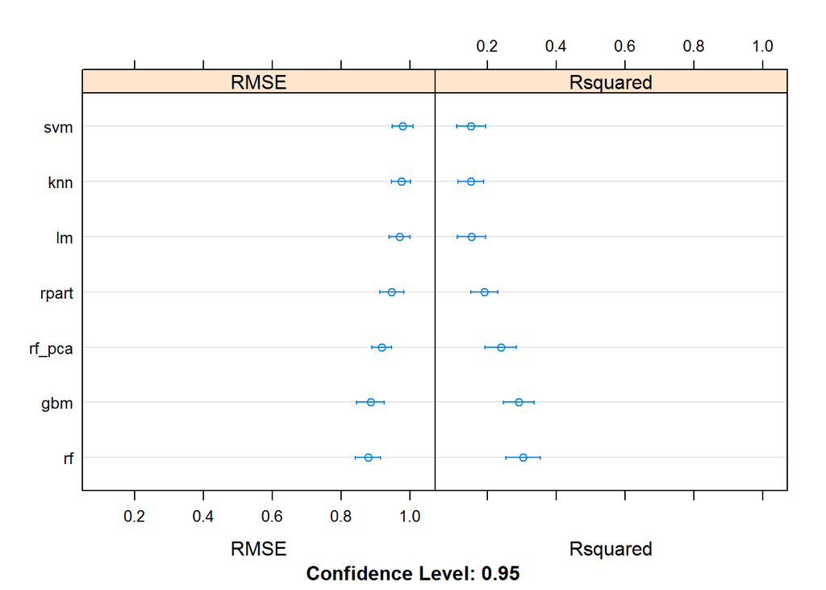

```r
dotplot(results)
```

```r
modelCor(results)
```

```
##               lm        rf       knn     rpart       svm    rf_pca
## lm     1.0000000 0.6930847 0.8789499 0.7607310 0.9473555 0.8538460
## rf     0.6930847 1.0000000 0.7441546 0.9189541 0.6919475 0.7977423
## knn    0.8789499 0.7441546 1.0000000 0.7975742 0.9006535 0.6866032
## rpart  0.7607310 0.9189541 0.7975742 1.0000000 0.7923252 0.7123579
## svm    0.9473555 0.6919475 0.9006535 0.7923252 1.0000000 0.7443156
## rf_pca 0.8538460 0.7977423 0.6866032 0.7123579 0.7443156 1.0000000
## gbm    0.7990830 0.9502209 0.8611473 0.9076928 0.8095756 0.8510603
##              gbm
## lm     0.7990830
## rf     0.9502209
## knn    0.8611473
## rpart  0.9076928
## svm    0.8095756
## rf_pca 0.8510603
## gbm    1.0000000
```

### Let’s try ensembling to see if performance enhances

High level steps are:

1. Train the individual base layer models on training data.
2. Predict using each base layer model for training data and test data. (One key thing to note here is that out of fold predictions are used while predicting for the training data).
3. Now train the top layer model again on the predictions of the bottom layer models that has been made on the training data.
4. Finally, predict using the top layer model with the predictions of bottom layer models that has been made for testing data.

### Step 1) is already done above.

Let’s combine different models to form an ensemble.

Two of the key principles for selecting the models:

- The individual models fulfill particular accuracy criteria.
- The model predictions of various individual models are not highly correlated with the predictions of other models.

Let’s try knn, rpart and rf_pca (as correlation is least)

### ensuring the data is proper

```r
movies_train1 <- movies_train1[,1:28]
movies_test1 <- movies_test1[,1:28]
```

### Step 2) Predict using each base layer model for training data and test data.

```r
#Taking the out of fold predictions for training data

movies_train1$OOF_pred_rpart<-model_rpart$pred$pred[order(model_rpart$pred$rowIndex)]
movies_train1$OOF_pred_knn<-model_knn$pred$pred[order(model_knn$pred$rowIndex)]
movies_train1$OOF_pred_rf_pca<-model_rf_pca$pred$pred[order(model_rf_pca$pred$rowIndex)]


#Taking Predicted values for the test data

movies_test1$OOF_pred_rpart<-predict(model_rpart,movies_test1[predictors])
movies_test1$OOF_pred_knn<-predict(model_knn,movies_test1[predictors])
movies_test1$OOF_pred_rf_pca<-predict(model_rf_pca,test.data)
```

### Step 3) Now train the top layer model again on the predictions of the bottom layer models that has been made on the training data.

```r
#Predictors for top layer models
predictors_top <- c('OOF_pred_rpart','OOF_pred_knn','OOF_pred_rf_pca')

set.seed(101)

#GBM as top layer model (Gradient Boosting)
model_gbm_top <- train(movies_train1[,predictors_top],movies_train1[,outcome],method='gbm',trControl=fitcontrol,verbose = FALSE)
#verbose: logical. Should R report extra information on progress? If TRUE then report progress
model_gbm_top
```

```
## Stochastic Gradient Boosting
##
## 2653 samples
##    3 predictor
##
## No pre-processing
## Resampling: Cross-Validated (10 fold)
## Summary of sample sizes: 2388, 2387, 2389, 2387, 2387, 2388, ...
## Resampling results across tuning parameters:
##
##   interaction.depth  n.trees  RMSE       Rsquared
##   1                   50      0.9044214  0.2607628
##   1                  100      0.9042123  0.2611132
##   1                  150      0.9042013  0.2616475
##   2                   50      0.9038244  0.2619573
##   2                  100      0.9049465  0.2601785
##   2                  150      0.9072823  0.2563510
##   3                   50      0.9050636  0.2602425
##   3                  100      0.9103313  0.2525690
##   3                  150      0.9114088  0.2523174
##
## Tuning parameter 'shrinkage' was held constant at a value of 0.1
##
## Tuning parameter 'n.minobsinnode' was held constant at a value of 10
## RMSE was used to select the optimal model using  the smallest value.
## The final values used for the model were n.trees = 50, interaction.depth
##  = 2, shrinkage = 0.1 and n.minobsinnode = 10.
```

### Step 4: Finally, predict using the top layer model with the predictions of bottom layer models that has been made for testing data

```r
#predict using GBM top layer model
movies_test1$gbm_stacked<-predict(model_gbm_top,movies_test1[,predictors_top])
```

```r
#calculating error measures
Error_measures(movies_test1$imdb_score,movies_test1$gbm_stacked)

RMSE;R2
```

```
## [1] 0.9203742
```

```
## [1] 0.2723318
```

Can infer that:

- Ensembling has resulted in enhanced performance compared to individual models (however it is less than rf_pca)

### Let’s try individual xgb model. It is regarded as the most powerful algorithm

### xgb Training

```r
set.seed(101)
library(xgboost)
```

```r
predictors2_exclude <- c("num_critic_for_reviews", "gross", "num_voted_users", "num_user_for_reviews", "movie_facebook_likes", "cast_total_facebook_likes", "genres", "plot_keywords", "movie_imdb_link", "director_name", "actor_1_name", "actor_2_name", "actor_3_name", "movie_title", "country", "imdb_score")


outcome <- "imdb_score"

predictors2 <- names(pca.train)[!(names(pca.train) %in% predictors2_exclude)]


model_xgb <- train(pca.train[,predictors2],
                 pca.train[,outcome],
                  method = 'xgbTree',
                  verbose = FALSE,
                  trControl = fitcontrol)


model_xgb
```

```
## eXtreme Gradient Boosting
##
## 2653 samples
##   64 predictor
##
## No pre-processing
## Resampling: Cross-Validated (10 fold)
## Summary of sample sizes: 2388, 2387, 2389, 2387, 2387, 2388, ...
## Resampling results across tuning parameters:
##
##   eta  max_depth  colsample_bytree  subsample  nrounds  RMSE
##   0.3  1          0.6               0.50        50      0.8922281
##   0.3  1          0.6               0.50       100      0.8901387
##   0.3  1          0.6               0.50       150      0.8933865
##   0.3  1          0.6               0.75        50      0.8886295
##   0.3  1          0.6               0.75       100      0.8830418
##   0.3  1          0.6               0.75       150      0.8844388
##   0.3  1          0.6               1.00        50      0.8909613
##   0.3  1          0.6               1.00       100      0.8835564
##   0.3  1          0.6               1.00       150      0.8827924
##   0.3  1          0.8               0.50        50      0.8907793
##   0.3  1          0.8               0.50       100      0.8873599
##   0.3  1          0.8               0.50       150      0.8872359
##   0.3  1          0.8               0.75        50      0.8915756
##   0.3  1          0.8               0.75       100      0.8834127
##   0.3  1          0.8               0.75       150      0.8859139
##   0.3  1          0.8               1.00        50      0.8925263
##   0.3  1          0.8               1.00       100      0.8836075
##   0.3  1          0.8               1.00       150      0.8824746
##   0.3  2          0.6               0.50        50      0.8825367
##   0.3  2          0.6               0.50       100      0.8908802
##   0.3  2          0.6               0.50       150      0.8992318
##   0.3  2          0.6               0.75        50      0.8737180
##   0.3  2          0.6               0.75       100      0.8714064
##   0.3  2          0.6               0.75       150      0.8767273
##   0.3  2          0.6               1.00        50      0.8764412
##   0.3  2          0.6               1.00       100      0.8757791
##   0.3  2          0.6               1.00       150      0.8765351
##   0.3  2          0.8               0.50        50      0.8824584
##   0.3  2          0.8               0.50       100      0.8850139
```

[output cut: 181 more lines]

```
##   0.2305670
##   0.2939866
##   0.2755395
##   0.2643188
##   0.2962089
##   0.2847601
##   0.2771458
##
## Tuning parameter 'gamma' was held constant at a value of 0
##
## Tuning parameter 'min_child_weight' was held constant at a value of 1
## RMSE was used to select the optimal model using  the smallest value.
## The final values used for the model were nrounds = 100, max_depth = 2,
##  eta = 0.4, gamma = 0, colsample_bytree = 0.6, min_child_weight = 1
##  and subsample = 1.
```

### xgb Validation

```r
#prediction
predict_model_xgb <- predict(model_xgb,pca.test[,predictors2])

#calculating error measures
Error_measures(pca.test$imdb_score,predict_model_xgb)


RMSE;R2
```

```
## [1] 0.8803701
```

```
## [1] 0.3342133
```

Can infer that:

- There is a significant improvement compared to ensemble model

### xgb importance variables

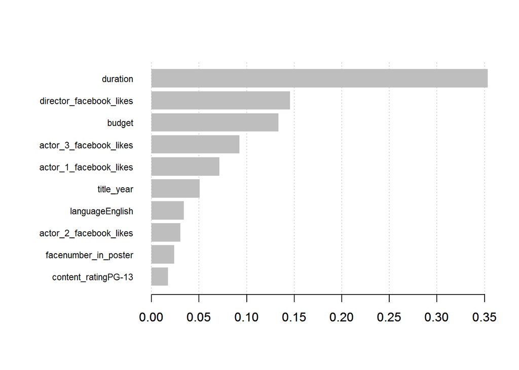

```r
importance_matrix <- xgb.importance(predictors2,model=model_xgb$finalModel)

xgb.plot.importance(importance_matrix,top_n=10)
```

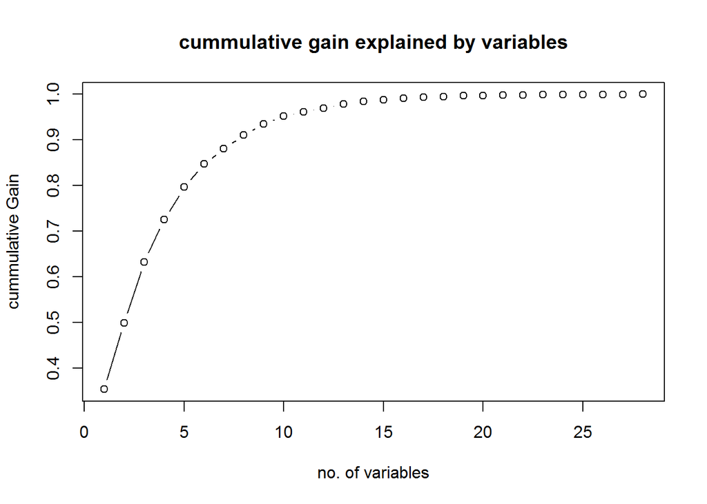

```r
plot(cumsum(importance_matrix$Gain),type='b',xlab='no. of variables',ylab='cummulative Gain',main='cummulative gain explained by variables')
```

```r
cumsum(importance_matrix$Gain)
```

```
##  [1] 0.3533660 0.4990006 0.6324818 0.7248678 0.7962992 0.8468444 0.8807275
##  [8] 0.9109178 0.9348173 0.9520015 0.9610457 0.9698220 0.9780492 0.9840890
## [15] 0.9881969 0.9908094 0.9930222 0.9950835 0.9965948 0.9975144 0.9981146
## [22] 0.9985599 0.9988569 0.9991288 0.9993898 0.9996410 0.9998644 1.0000000
```

```r
cat('\nThe important variables to the model are:\n')
```

```
##
## The important variables to the model are:
```

```r
importance_matrix$Feature
```

```
##  [1] "duration"                "director_facebook_likes"
##  [3] "budget"                  "actor_3_facebook_likes"
##  [5] "actor_1_facebook_likes"  "title_year"
##  [7] "languageEnglish"         "actor_2_facebook_likes"
##  [9] "facenumber_in_poster"    "content_ratingPG-13"
## [11] "color Black and White"   "languageBosnian"
## [13] "content_ratingG"         "aspect_ratio"
## [15] "content_ratingR"         "languageHindi"
## [17] "language"                "languageFrench"
## [19] "languageDanish"          "content_ratingNot Rated"
## [21] "languageItalian"         "content_ratingX"
## [23] "languageGerman"          "languageRussian"
## [25] "languageCantonese"       "languageKazakh"
## [27] "languageTelugu"          "content_ratingApproved"
```

### Lets run the xgb model again with important variables alone

```r
set.seed(101)
library(xgboost)

model_xgb <- train(pca.train[,importance_matrix$Feature],
                 pca.train[,outcome],
                  method = 'xgbTree',
                  verbose = FALSE,
                  trControl = fitcontrol)


model_xgb
```

```
## eXtreme Gradient Boosting
##
## 2653 samples
##   28 predictor
##
## No pre-processing
## Resampling: Cross-Validated (10 fold)
## Summary of sample sizes: 2388, 2387, 2389, 2387, 2387, 2388, ...
## Resampling results across tuning parameters:
##
##   eta  max_depth  colsample_bytree  subsample  nrounds  RMSE
##   0.3  1          0.6               0.50        50      0.8946524
##   0.3  1          0.6               0.50       100      0.8872781
##   0.3  1          0.6               0.50       150      0.8901396
##   0.3  1          0.6               0.75        50      0.8895880
##   0.3  1          0.6               0.75       100      0.8853562
##   0.3  1          0.6               0.75       150      0.8836394
##   0.3  1          0.6               1.00        50      0.8917028
##   0.3  1          0.6               1.00       100      0.8835844
##   0.3  1          0.6               1.00       150      0.8828267
##   0.3  1          0.8               0.50        50      0.8883013
##   0.3  1          0.8               0.50       100      0.8845475
##   0.3  1          0.8               0.50       150      0.8849913
##   0.3  1          0.8               0.75        50      0.8910639
##   0.3  1          0.8               0.75       100      0.8843048
##   0.3  1          0.8               0.75       150      0.8850533
##   0.3  1          0.8               1.00        50      0.8923003
##   0.3  1          0.8               1.00       100      0.8842679
##   0.3  1          0.8               1.00       150      0.8826318
##   0.3  2          0.6               0.50        50      0.8813080
##   0.3  2          0.6               0.50       100      0.8835352
##   0.3  2          0.6               0.50       150      0.8843988
##   0.3  2          0.6               0.75        50      0.8777781
##   0.3  2          0.6               0.75       100      0.8810178
##   0.3  2          0.6               0.75       150      0.8881723
##   0.3  2          0.6               1.00        50      0.8751177
##   0.3  2          0.6               1.00       100      0.8747126
##   0.3  2          0.6               1.00       150      0.8742345
##   0.3  2          0.8               0.50        50      0.8905463
##   0.3  2          0.8               0.50       100      0.8915620
```

[output cut: 181 more lines]

```
##   0.2513569
##   0.2739287
##   0.2582501
##   0.2476632
##   0.2892213
##   0.2818789
##   0.2747399
##
## Tuning parameter 'gamma' was held constant at a value of 0
##
## Tuning parameter 'min_child_weight' was held constant at a value of 1
## RMSE was used to select the optimal model using  the smallest value.
## The final values used for the model were nrounds = 50, max_depth = 3,
##  eta = 0.3, gamma = 0, colsample_bytree = 0.6, min_child_weight = 1
##  and subsample = 1.
```

### validate to see if we get better results

```r
#prediction
predict_model_xgb <- predict(model_xgb,pca.test[,importance_matrix$Feature])

#calculating error measures
Error_measures(pca.test$imdb_score,predict_model_xgb)


RMSE;R2
```

```
## [1] 0.8671462
```

```
## [1] 0.3540645
```

Conclusion:

- This is the best performance we have.
- Got better RMSE of 0.86 and Rsquared of 0.35(The proportion of variance explained by the best model is 35%)
- Ideally we would like to have better Rsquared value but since we included fields corresponding to pre-release only this sort of a result is understandable
- Without relying on critics or our own instincts, We can conclude that greatness of the movie is dependent on:
  - Duration : The longer the movie, the better is the rating
  - Director popularity on facebook
  - Budget (although we have seen earlier that budget has got very less correlation with rating)
  - Top 3 actors popularity on facebook
  - Title year
  - Language (English seem to be getting more ratings)
  - Facenumber in poster
  - Content rating (PG-13 seem be influencing ratings more)